# Risk Factor Analysis

## Outcome Variable

**Outcome Variable:** stunted

## Predictor Variables

**Intervention Variable:** birthwt

**Adjustment Set:**

unadjusted

## Stratifying Variables

The analysis was stratified on these variable(s):

- agecat
- studyid
- country

## Data Summary

| agecat | studyid | country | birthwt | stunted | n_cell | n |
| --- | --- | --- | --- | --- | --- | --- |
| Birth | ki0047075b-MAL-ED | BANGLADESH | >=0 | 0 | 34 | 257 |
| Birth | ki0047075b-MAL-ED | BANGLADESH | >=0 | 1 | 0 | 257 |
| Birth | ki0047075b-MAL-ED | BANGLADESH | <-3 | 0 | 0 | 257 |
| Birth | ki0047075b-MAL-ED | BANGLADESH | <-3 | 1 | 7 | 257 |
| Birth | ki0047075b-MAL-ED | BANGLADESH | [-3–2) | 0 | 16 | 257 |
| Birth | ki0047075b-MAL-ED | BANGLADESH | [-3–2) | 1 | 22 | 257 |
| Birth | ki0047075b-MAL-ED | BANGLADESH | [-2–1) | 0 | 82 | 257 |
| Birth | ki0047075b-MAL-ED | BANGLADESH | [-2–1) | 1 | 14 | 257 |
| Birth | ki0047075b-MAL-ED | BANGLADESH | [-1-0) | 0 | 78 | 257 |
| Birth | ki0047075b-MAL-ED | BANGLADESH | [-1-0) | 1 | 4 | 257 |
| 6 months | ki0047075b-MAL-ED | BANGLADESH | >=0 | 0 | 32 | 234 |
| 6 months | ki0047075b-MAL-ED | BANGLADESH | >=0 | 1 | 1 | 234 |
| 6 months | ki0047075b-MAL-ED | BANGLADESH | <-3 | 0 | 2 | 234 |
| 6 months | ki0047075b-MAL-ED | BANGLADESH | <-3 | 1 | 2 | 234 |
| 6 months | ki0047075b-MAL-ED | BANGLADESH | [-3–2) | 0 | 19 | 234 |
| 6 months | ki0047075b-MAL-ED | BANGLADESH | [-3–2) | 1 | 15 | 234 |
| 6 months | ki0047075b-MAL-ED | BANGLADESH | [-2–1) | 0 | 70 | 234 |
| 6 months | ki0047075b-MAL-ED | BANGLADESH | [-2–1) | 1 | 16 | 234 |
| 6 months | ki0047075b-MAL-ED | BANGLADESH | [-1-0) | 0 | 68 | 234 |
| 6 months | ki0047075b-MAL-ED | BANGLADESH | [-1-0) | 1 | 9 | 234 |
| 24 months | ki0047075b-MAL-ED | BANGLADESH | >=0 | 0 | 27 | 207 |
| 24 months | ki0047075b-MAL-ED | BANGLADESH | >=0 | 1 | 4 | 207 |
| 24 months | ki0047075b-MAL-ED | BANGLADESH | <-3 | 0 | 0 | 207 |
| 24 months | ki0047075b-MAL-ED | BANGLADESH | <-3 | 1 | 4 | 207 |
| 24 months | ki0047075b-MAL-ED | BANGLADESH | [-3–2) | 0 | 10 | 207 |
| 24 months | ki0047075b-MAL-ED | BANGLADESH | [-3–2) | 1 | 19 | 207 |
| 24 months | ki0047075b-MAL-ED | BANGLADESH | [-2–1) | 0 | 38 | 207 |
| 24 months | ki0047075b-MAL-ED | BANGLADESH | [-2–1) | 1 | 35 | 207 |
| 24 months | ki0047075b-MAL-ED | BANGLADESH | [-1-0) | 0 | 38 | 207 |
| 24 months | ki0047075b-MAL-ED | BANGLADESH | [-1-0) | 1 | 32 | 207 |

[output cut: 634 more lines]

The following strata were considered:

- agecat: 24 months, studyid: ki0047075b-MAL-ED, country: BANGLADESH
- agecat: 24 months, studyid: ki0047075b-MAL-ED, country: BRAZIL
- agecat: 24 months, studyid: ki0047075b-MAL-ED, country: INDIA
- agecat: 24 months, studyid: ki0047075b-MAL-ED, country: NEPAL
- agecat: 24 months, studyid: ki0047075b-MAL-ED, country: PERU
- agecat: 24 months, studyid: ki0047075b-MAL-ED, country: SOUTH AFRICA
- agecat: 24 months, studyid: ki0047075b-MAL-ED, country: TANZANIA, UNITED REPUBLIC OF
- agecat: 24 months, studyid: ki1000108-CMC-V-BCS-2002, country: INDIA
- agecat: 24 months, studyid: ki1000108-IRC, country: INDIA
- agecat: 24 months, studyid: ki1017093-NIH-Birth, country: BANGLADESH
- agecat: 24 months, studyid: ki1017093b-PROVIDE, country: BANGLADESH
- agecat: 24 months, studyid: ki1017093c-NIH-Crypto, country: BANGLADESH
- agecat: 24 months, studyid: ki1066203-TanzaniaChild2, country: TANZANIA, UNITED REPUBLIC OF
- agecat: 24 months, studyid: ki1101329-Keneba, country: GAMBIA
- agecat: 24 months, studyid: ki1114097-CMIN, country: PERU
- agecat: 24 months, studyid: ki1114097-CONTENT, country: PERU
- agecat: 24 months, studyid: ki1119695-PROBIT, country: BELARUS
- agecat: 24 months, studyid: ki1126311-ZVITAMBO, country: ZIMBABWE
- agecat: 24 months, studyid: ki1135781-COHORTS, country: GUATEMALA
- agecat: 24 months, studyid: ki1135781-COHORTS, country: INDIA
- agecat: 24 months, studyid: ki1135781-COHORTS, country: PHILIPPINES
- agecat: 24 months, studyid: kiGH5241-JiVitA-3, country: BANGLADESH
- agecat: 24 months, studyid: kiGH5241-JiVitA-4, country: BANGLADESH
- agecat: 6 months, studyid: ki0047075b-MAL-ED, country: BANGLADESH
- agecat: 6 months, studyid: ki0047075b-MAL-ED, country: BRAZIL
- agecat: 6 months, studyid: ki0047075b-MAL-ED, country: INDIA
- agecat: 6 months, studyid: ki0047075b-MAL-ED, country: NEPAL
- agecat: 6 months, studyid: ki0047075b-MAL-ED, country: PERU
- agecat: 6 months, studyid: ki0047075b-MAL-ED, country: SOUTH AFRICA
- agecat: 6 months, studyid: ki0047075b-MAL-ED, country: TANZANIA, UNITED REPUBLIC OF
- agecat: 6 months, studyid: ki1000108-CMC-V-BCS-2002, country: INDIA
- agecat: 6 months, studyid: ki1000108-IRC, country: INDIA
- agecat: 6 months, studyid: ki1000109-EE, country: PAKISTAN
- agecat: 6 months, studyid: ki1000109-ResPak, country: PAKISTAN
- agecat: 6 months, studyid: ki1000304b-SAS-CompFeed, country: INDIA
- agecat: 6 months, studyid: ki1017093-NIH-Birth, country: BANGLADESH
- agecat: 6 months, studyid: ki1017093b-PROVIDE, country: BANGLADESH
- agecat: 6 months, studyid: ki1017093c-NIH-Crypto, country: BANGLADESH
- agecat: 6 months, studyid: ki1066203-TanzaniaChild2, country: TANZANIA, UNITED REPUBLIC OF
- agecat: 6 months, studyid: ki1101329-Keneba, country: GAMBIA
- agecat: 6 months, studyid: ki1114097-CMIN, country: BRAZIL
- agecat: 6 months, studyid: ki1114097-CMIN, country: PERU
- agecat: 6 months, studyid: ki1114097-CONTENT, country: PERU
- agecat: 6 months, studyid: ki1119695-PROBIT, country: BELARUS
- agecat: 6 months, studyid: ki1126311-ZVITAMBO, country: ZIMBABWE
- agecat: 6 months, studyid: ki1135781-COHORTS, country: GUATEMALA
- agecat: 6 months, studyid: ki1135781-COHORTS, country: INDIA
- agecat: 6 months, studyid: ki1135781-COHORTS, country: PHILIPPINES
- agecat: 6 months, studyid: kiGH5241-JiVitA-3, country: BANGLADESH
- agecat: 6 months, studyid: kiGH5241-JiVitA-4, country: BANGLADESH
- agecat: Birth, studyid: ki0047075b-MAL-ED, country: BANGLADESH
- agecat: Birth, studyid: ki0047075b-MAL-ED, country: BRAZIL
- agecat: Birth, studyid: ki0047075b-MAL-ED, country: INDIA
- agecat: Birth, studyid: ki0047075b-MAL-ED, country: NEPAL
- agecat: Birth, studyid: ki0047075b-MAL-ED, country: PERU
- agecat: Birth, studyid: ki0047075b-MAL-ED, country: SOUTH AFRICA
- agecat: Birth, studyid: ki0047075b-MAL-ED, country: TANZANIA, UNITED REPUBLIC OF
- agecat: Birth, studyid: ki1000108-CMC-V-BCS-2002, country: INDIA
- agecat: Birth, studyid: ki1000108-IRC, country: INDIA
- agecat: Birth, studyid: ki1000109-EE, country: PAKISTAN
- agecat: Birth, studyid: ki1000109-ResPak, country: PAKISTAN
- agecat: Birth, studyid: ki1000304b-SAS-CompFeed, country: INDIA
- agecat: Birth, studyid: ki1017093-NIH-Birth, country: BANGLADESH
- agecat: Birth, studyid: ki1017093c-NIH-Crypto, country: BANGLADESH
- agecat: Birth, studyid: ki1101329-Keneba, country: GAMBIA
- agecat: Birth, studyid: ki1114097-CMIN, country: BANGLADESH
- agecat: Birth, studyid: ki1114097-CMIN, country: BRAZIL
- agecat: Birth, studyid: ki1114097-CMIN, country: PERU
- agecat: Birth, studyid: ki1114097-CONTENT, country: PERU
- agecat: Birth, studyid: ki1119695-PROBIT, country: BELARUS
- agecat: Birth, studyid: ki1126311-ZVITAMBO, country: ZIMBABWE
- agecat: Birth, studyid: ki1135781-COHORTS, country: GUATEMALA
- agecat: Birth, studyid: ki1135781-COHORTS, country: INDIA
- agecat: Birth, studyid: ki1135781-COHORTS, country: PHILIPPINES
- agecat: Birth, studyid: kiGH5241-JiVitA-3, country: BANGLADESH
- agecat: Birth, studyid: kiGH5241-JiVitA-4, country: BANGLADESH

### Dropped Strata

Some strata were dropped due to rare outcomes:

- agecat: Birth, studyid: ki0047075b-MAL-ED, country: BANGLADESH
- agecat: 6 months, studyid: ki0047075b-MAL-ED, country: BANGLADESH
- agecat: 24 months, studyid: ki0047075b-MAL-ED, country: BANGLADESH
- agecat: Birth, studyid: ki0047075b-MAL-ED, country: BRAZIL
- agecat: 6 months, studyid: ki0047075b-MAL-ED, country: BRAZIL
- agecat: 24 months, studyid: ki0047075b-MAL-ED, country: BRAZIL
- agecat: Birth, studyid: ki0047075b-MAL-ED, country: INDIA
- agecat: 6 months, studyid: ki0047075b-MAL-ED, country: INDIA
- agecat: 24 months, studyid: ki0047075b-MAL-ED, country: INDIA
- agecat: Birth, studyid: ki0047075b-MAL-ED, country: NEPAL
- agecat: 6 months, studyid: ki0047075b-MAL-ED, country: NEPAL
- agecat: 24 months, studyid: ki0047075b-MAL-ED, country: NEPAL
- agecat: Birth, studyid: ki0047075b-MAL-ED, country: PERU
- agecat: 6 months, studyid: ki0047075b-MAL-ED, country: PERU
- agecat: 24 months, studyid: ki0047075b-MAL-ED, country: PERU
- agecat: Birth, studyid: ki0047075b-MAL-ED, country: SOUTH AFRICA
- agecat: 6 months, studyid: ki0047075b-MAL-ED, country: SOUTH AFRICA
- agecat: 24 months, studyid: ki0047075b-MAL-ED, country: SOUTH AFRICA
- agecat: Birth, studyid: ki0047075b-MAL-ED, country: TANZANIA, UNITED REPUBLIC OF
- agecat: 6 months, studyid: ki0047075b-MAL-ED, country: TANZANIA, UNITED REPUBLIC OF
- agecat: 24 months, studyid: ki0047075b-MAL-ED, country: TANZANIA, UNITED REPUBLIC OF
- agecat: 6 months, studyid: ki1000108-CMC-V-BCS-2002, country: INDIA
- agecat: 24 months, studyid: ki1000108-CMC-V-BCS-2002, country: INDIA
- agecat: Birth, studyid: ki1000108-CMC-V-BCS-2002, country: INDIA
- agecat: 24 months, studyid: ki1000108-IRC, country: INDIA
- agecat: Birth, studyid: ki1000108-IRC, country: INDIA
- agecat: Birth, studyid: ki1000109-EE, country: PAKISTAN
- agecat: Birth, studyid: ki1000109-ResPak, country: PAKISTAN
- agecat: 6 months, studyid: ki1000109-ResPak, country: PAKISTAN
- agecat: Birth, studyid: ki1000304b-SAS-CompFeed, country: INDIA
- agecat: Birth, studyid: ki1017093-NIH-Birth, country: BANGLADESH
- agecat: 6 months, studyid: ki1017093-NIH-Birth, country: BANGLADESH
- agecat: 24 months, studyid: ki1017093-NIH-Birth, country: BANGLADESH
- agecat: 6 months, studyid: ki1017093b-PROVIDE, country: BANGLADESH
- agecat: 24 months, studyid: ki1017093b-PROVIDE, country: BANGLADESH
- agecat: Birth, studyid: ki1017093c-NIH-Crypto, country: BANGLADESH
- agecat: 24 months, studyid: ki1017093c-NIH-Crypto, country: BANGLADESH
- agecat: 24 months, studyid: ki1066203-TanzaniaChild2, country: TANZANIA, UNITED REPUBLIC OF
- agecat: Birth, studyid: ki1101329-Keneba, country: GAMBIA
- agecat: Birth, studyid: ki1114097-CMIN, country: BANGLADESH
- agecat: Birth, studyid: ki1114097-CMIN, country: BRAZIL
- agecat: 6 months, studyid: ki1114097-CMIN, country: BRAZIL
- agecat: Birth, studyid: ki1114097-CMIN, country: PERU
- agecat: 6 months, studyid: ki1114097-CMIN, country: PERU
- agecat: 24 months, studyid: ki1114097-CMIN, country: PERU
- agecat: Birth, studyid: ki1114097-CONTENT, country: PERU
- agecat: 6 months, studyid: ki1114097-CONTENT, country: PERU
- agecat: 24 months, studyid: ki1114097-CONTENT, country: PERU
- agecat: Birth, studyid: ki1119695-PROBIT, country: BELARUS
- agecat: 24 months, studyid: ki1126311-ZVITAMBO, country: ZIMBABWE
- agecat: Birth, studyid: ki1135781-COHORTS, country: GUATEMALA
- agecat: 6 months, studyid: ki1135781-COHORTS, country: GUATEMALA
- agecat: 24 months, studyid: ki1135781-COHORTS, country: GUATEMALA
- agecat: Birth, studyid: ki1135781-COHORTS, country: PHILIPPINES
- agecat: Birth, studyid: kiGH5241-JiVitA-3, country: BANGLADESH
- agecat: Birth, studyid: kiGH5241-JiVitA-4, country: BANGLADESH

## Methods Detail

We’re interested in the causal parameters $E[Y_a]$ for all values of $a \in \mathcal{A}$. These parameters represent the mean outcome if, possibly contrary to fact, we intervened to set all units to have $A=a$. Under the randomization and positivity assumptions, these are identified by the statistical parameters $\psi_a=E_W[E_{Y|A,W}(Y|A=a,W)]$. In addition, we’re interested in the mean of $Y$, $E[Y]$ under no intervention (the observed mean). We will estimate these parameters by using SuperLearner to fit the relevant likelihood factors – $E_{Y|A,W}(Y|A=a,W)$ and $p(A=a|W)$, and then updating our likelihood fit using a joint TMLE.

For unadjusted analyses ($W=\{\}$), initial likelihoods were estimated using Lrnr_glm to estimate the simple $E(Y|A)$ and Lrnr_mean to estimate $p(A)$. For adjusted analyses, a small library containing Lrnr_glmnet, Lrnr_xgboost, and Lrnr_mean was used.

Having estimated these parameters, we will then use the delta method to estimate relative risks and attributable risks relative to a prespecified baseline level of $A$.

# Results Detail

## Results Plots

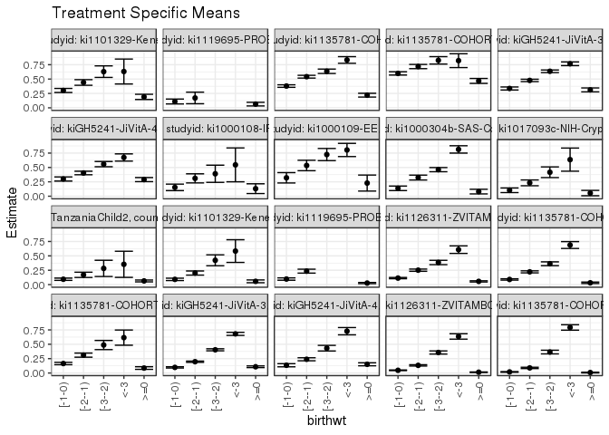

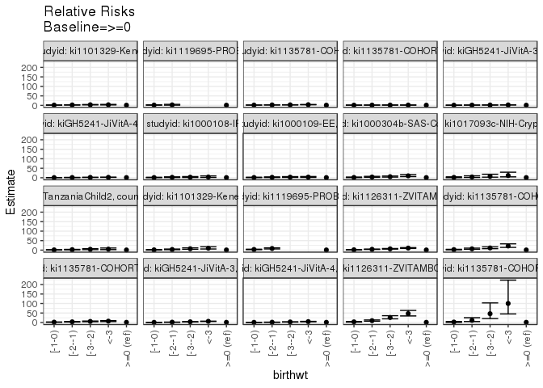

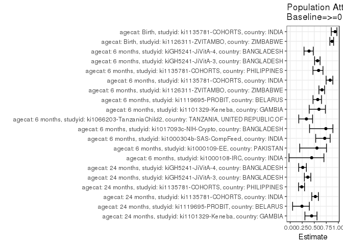

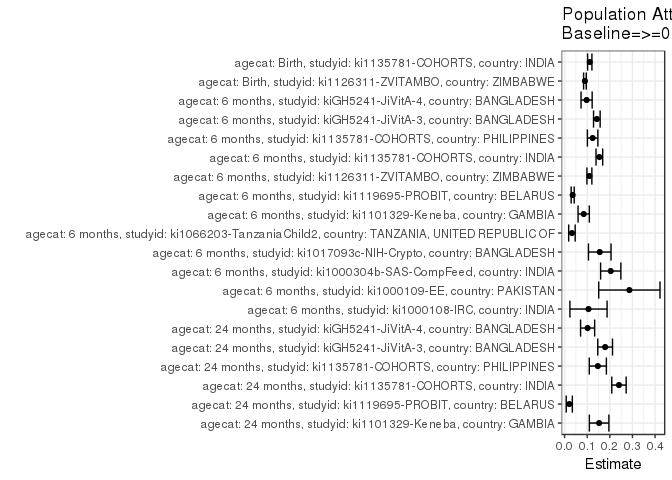

## Results Table

### Parameter: TSM

| agecat | studyid | country | intervention_level | baseline_level | estimate | ci_lower | ci_upper |
| --- | --- | --- | --- | --- | --- | --- | --- |
| Birth | ki1126311-ZVITAMBO | ZIMBABWE | >=0 | NA | 0.0135604 | 0.0095347 | 0.0175861 |
| Birth | ki1126311-ZVITAMBO | ZIMBABWE | <-3 | NA | 0.6361386 | 0.5892230 | 0.6830542 |
| Birth | ki1126311-ZVITAMBO | ZIMBABWE | [-3–2) | NA | 0.3566553 | 0.3292303 | 0.3840803 |
| Birth | ki1126311-ZVITAMBO | ZIMBABWE | [-2–1) | NA | 0.1330344 | 0.1215251 | 0.1445437 |
| Birth | ki1126311-ZVITAMBO | ZIMBABWE | [-1-0) | NA | 0.0468804 | 0.0414109 | 0.0523500 |
| Birth | ki1135781-COHORTS | INDIA | >=0 | NA | 0.0078947 | 0.0016023 | 0.0141872 |
| Birth | ki1135781-COHORTS | INDIA | <-3 | NA | 0.7922535 | 0.7450667 | 0.8394403 |
| Birth | ki1135781-COHORTS | INDIA | [-3–2) | NA | 0.3646922 | 0.3325383 | 0.3968462 |
| Birth | ki1135781-COHORTS | INDIA | [-2–1) | NA | 0.0886525 | 0.0769225 | 0.1003825 |
| Birth | ki1135781-COHORTS | INDIA | [-1-0) | NA | 0.0185784 | 0.0132593 | 0.0238974 |
| 6 months | ki1000108-IRC | INDIA | >=0 | NA | 0.1311475 | 0.0463314 | 0.2159637 |
| 6 months | ki1000108-IRC | INDIA | <-3 | NA | 0.5454545 | 0.2508348 | 0.8400743 |
| 6 months | ki1000108-IRC | INDIA | [-3–2) | NA | 0.3902439 | 0.2407428 | 0.5397450 |
| 6 months | ki1000108-IRC | INDIA | [-2–1) | NA | 0.3106061 | 0.2315670 | 0.3896452 |
| 6 months | ki1000108-IRC | INDIA | [-1-0) | NA | 0.1538462 | 0.0971575 | 0.2105348 |
| 6 months | ki1000109-EE | PAKISTAN | >=0 | NA | 0.2285714 | 0.0892679 | 0.3678750 |
| 6 months | ki1000109-EE | PAKISTAN | <-3 | NA | 0.8043478 | 0.6895529 | 0.9191428 |
| 6 months | ki1000109-EE | PAKISTAN | [-3–2) | NA | 0.7246377 | 0.6190956 | 0.8301797 |
| 6 months | ki1000109-EE | PAKISTAN | [-2–1) | NA | 0.5344828 | 0.4435871 | 0.6253784 |
| 6 months | ki1000109-EE | PAKISTAN | [-1-0) | NA | 0.3203883 | 0.2301508 | 0.4106259 |
| 6 months | ki1000304b-SAS-CompFeed | INDIA | >=0 | NA | 0.0802920 | 0.0397919 | 0.1207921 |
| 6 months | ki1000304b-SAS-CompFeed | INDIA | <-3 | NA | 0.8139535 | 0.7499173 | 0.8779897 |
| 6 months | ki1000304b-SAS-CompFeed | INDIA | [-3–2) | NA | 0.4619565 | 0.4258341 | 0.4980790 |
| 6 months | ki1000304b-SAS-CompFeed | INDIA | [-2–1) | NA | 0.3245033 | 0.2818446 | 0.3671620 |
| 6 months | ki1000304b-SAS-CompFeed | INDIA | [-1-0) | NA | 0.1373391 | 0.0979097 | 0.1767684 |
| 6 months | ki1017093c-NIH-Crypto | BANGLADESH | >=0 | NA | 0.0543478 | 0.0079909 | 0.1007048 |
| 6 months | ki1017093c-NIH-Crypto | BANGLADESH | <-3 | NA | 0.6363636 | 0.4352104 | 0.8375169 |
| 6 months | ki1017093c-NIH-Crypto | BANGLADESH | [-3–2) | NA | 0.4166667 | 0.3236217 | 0.5097116 |
| 6 months | ki1017093c-NIH-Crypto | BANGLADESH | [-2–1) | NA | 0.2324723 | 0.1821454 | 0.2827992 |
| 6 months | ki1017093c-NIH-Crypto | BANGLADESH | [-1-0) | NA | 0.1036036 | 0.0634880 | 0.1437192 |

[output cut: 66 more lines]

### Parameter: E(Y)

| agecat | studyid | country | intervention_level | baseline_level | estimate | ci_lower | ci_upper |
| --- | --- | --- | --- | --- | --- | --- | --- |
| Birth | ki1126311-ZVITAMBO | ZIMBABWE | NA | NA | 0.1035430 | 0.0984652 | 0.1086208 |
| Birth | ki1135781-COHORTS | INDIA | NA | NA | 0.1191804 | 0.1113849 | 0.1269758 |
| 6 months | ki1000108-IRC | INDIA | NA | NA | 0.2369077 | 0.1952403 | 0.2785751 |
| 6 months | ki1000109-EE | PAKISTAN | NA | NA | 0.5149051 | 0.4638428 | 0.5659675 |
| 6 months | ki1000304b-SAS-CompFeed | INDIA | NA | NA | 0.2843137 | 0.2660295 | 0.3025980 |
| 6 months | ki1017093c-NIH-Crypto | BANGLADESH | NA | NA | 0.2097902 | 0.1799252 | 0.2396552 |
| 6 months | ki1066203-TanzaniaChild2 | TANZANIA, UNITED REPUBLIC OF | NA | NA | 0.0965174 | 0.0836046 | 0.1094302 |
| 6 months | ki1101329-Keneba | GAMBIA | NA | NA | 0.1415313 | 0.1250727 | 0.1579900 |
| 6 months | ki1119695-PROBIT | BELARUS | NA | NA | 0.0626864 | 0.0488489 | 0.0765238 |
| 6 months | ki1126311-ZVITAMBO | ZIMBABWE | NA | NA | 0.1660012 | 0.1579791 | 0.1740234 |
| 6 months | ki1135781-COHORTS | INDIA | NA | NA | 0.1852739 | 0.1756495 | 0.1948983 |
| 6 months | ki1135781-COHORTS | PHILIPPINES | NA | NA | 0.2102102 | 0.1947347 | 0.2256857 |
| 6 months | kiGH5241-JiVitA-3 | BANGLADESH | NA | NA | 0.2511506 | 0.2430432 | 0.2592580 |
| 6 months | kiGH5241-JiVitA-4 | BANGLADESH | NA | NA | 0.2488856 | 0.2327574 | 0.2650138 |
| 24 months | ki1101329-Keneba | GAMBIA | NA | NA | 0.3428571 | 0.3182897 | 0.3674246 |
| 24 months | ki1119695-PROBIT | BELARUS | NA | NA | 0.0852540 | 0.0554439 | 0.1150642 |
| 24 months | ki1135781-COHORTS | INDIA | NA | NA | 0.4603991 | 0.4463860 | 0.4744122 |
| 24 months | ki1135781-COHORTS | PHILIPPINES | NA | NA | 0.6152246 | 0.5957714 | 0.6346779 |
| 24 months | kiGH5241-JiVitA-3 | BANGLADESH | NA | NA | 0.4909070 | 0.4777319 | 0.5040821 |
| 24 months | kiGH5241-JiVitA-4 | BANGLADESH | NA | NA | 0.3905665 | 0.3719151 | 0.4092179 |

### Parameter: RR

| agecat | studyid | country | intervention_level | baseline_level | estimate | ci_lower | ci_upper |
| --- | --- | --- | --- | --- | --- | --- | --- |
| Birth | ki1126311-ZVITAMBO | ZIMBABWE | >=0 | >=0 | 1.0000000 | 1.0000000 | 1.000000 |
| Birth | ki1126311-ZVITAMBO | ZIMBABWE | <-3 | >=0 | 46.9115243 | 34.5487263 | 63.698183 |
| Birth | ki1126311-ZVITAMBO | ZIMBABWE | [-3–2) | >=0 | 26.3012541 | 19.3549975 | 35.740432 |
| Birth | ki1126311-ZVITAMBO | ZIMBABWE | [-2–1) | >=0 | 9.8105120 | 7.2011189 | 13.365443 |
| Birth | ki1126311-ZVITAMBO | ZIMBABWE | [-1-0) | >=0 | 3.4571603 | 2.5129954 | 4.756060 |
| Birth | ki1135781-COHORTS | INDIA | >=0 | >=0 | 1.0000000 | 1.0000000 | 1.000000 |
| Birth | ki1135781-COHORTS | INDIA | <-3 | >=0 | 100.3521122 | 45.1240621 | 223.174642 |
| Birth | ki1135781-COHORTS | INDIA | [-3–2) | >=0 | 46.1943474 | 20.7168753 | 103.003841 |
| Birth | ki1135781-COHORTS | INDIA | [-2–1) | >=0 | 11.2293144 | 5.0056767 | 25.190900 |
| Birth | ki1135781-COHORTS | INDIA | [-1-0) | >=0 | 2.3532579 | 1.0089312 | 5.488801 |
| 6 months | ki1000108-IRC | INDIA | >=0 | >=0 | 1.0000000 | 1.0000000 | 1.000000 |
| 6 months | ki1000108-IRC | INDIA | <-3 | >=0 | 4.1590909 | 1.7908365 | 9.659194 |
| 6 months | ki1000108-IRC | INDIA | [-3–2) | >=0 | 2.9756098 | 1.4032277 | 6.309919 |
| 6 months | ki1000108-IRC | INDIA | [-2–1) | >=0 | 2.3683712 | 1.1820112 | 4.745456 |
| 6 months | ki1000108-IRC | INDIA | [-1-0) | >=0 | 1.1730769 | 0.5572738 | 2.469360 |
| 6 months | ki1000109-EE | PAKISTAN | >=0 | >=0 | 1.0000000 | 1.0000000 | 1.000000 |
| 6 months | ki1000109-EE | PAKISTAN | <-3 | >=0 | 3.5190217 | 1.8818261 | 6.580584 |
| 6 months | ki1000109-EE | PAKISTAN | [-3–2) | >=0 | 3.1702899 | 1.6941956 | 5.932454 |
| 6 months | ki1000109-EE | PAKISTAN | [-2–1) | >=0 | 2.3383621 | 1.2419902 | 4.402561 |
| 6 months | ki1000109-EE | PAKISTAN | [-1-0) | >=0 | 1.4016990 | 0.7162675 | 2.743054 |
| 6 months | ki1000304b-SAS-CompFeed | INDIA | >=0 | >=0 | 1.0000000 | 1.0000000 | 1.000000 |
| 6 months | ki1000304b-SAS-CompFeed | INDIA | <-3 | >=0 | 10.1374207 | 6.1562844 | 16.693072 |
| 6 months | ki1000304b-SAS-CompFeed | INDIA | [-3–2) | >=0 | 5.7534585 | 3.6080093 | 9.174667 |
| 6 months | ki1000304b-SAS-CompFeed | INDIA | [-2–1) | >=0 | 4.0415412 | 2.2599422 | 7.227643 |
| 6 months | ki1000304b-SAS-CompFeed | INDIA | [-1-0) | >=0 | 1.7104955 | 0.8262022 | 3.541258 |
| 6 months | ki1017093c-NIH-Crypto | BANGLADESH | >=0 | >=0 | 1.0000000 | 1.0000000 | 1.000000 |
| 6 months | ki1017093c-NIH-Crypto | BANGLADESH | <-3 | >=0 | 11.7090909 | 4.7148190 | 29.079124 |
| 6 months | ki1017093c-NIH-Crypto | BANGLADESH | [-3–2) | >=0 | 7.6666667 | 3.1745543 | 18.515285 |
| 6 months | ki1017093c-NIH-Crypto | BANGLADESH | [-2–1) | >=0 | 4.2774908 | 1.7742096 | 10.312720 |
| 6 months | ki1017093c-NIH-Crypto | BANGLADESH | [-1-0) | >=0 | 1.9063063 | 0.7470885 | 4.864221 |

[output cut: 66 more lines]

### Parameter: PAR

| agecat | studyid | country | intervention_level | baseline_level | estimate | ci_lower | ci_upper |
| --- | --- | --- | --- | --- | --- | --- | --- |
| Birth | ki1126311-ZVITAMBO | ZIMBABWE | >=0 | NA | 0.0899826 | 0.0841040 | 0.0958613 |
| Birth | ki1135781-COHORTS | INDIA | >=0 | NA | 0.1112856 | 0.1017307 | 0.1208405 |
| 6 months | ki1000108-IRC | INDIA | >=0 | NA | 0.1057602 | 0.0236547 | 0.1878657 |
| 6 months | ki1000109-EE | PAKISTAN | >=0 | NA | 0.2863337 | 0.1509395 | 0.4217279 |
| 6 months | ki1000304b-SAS-CompFeed | INDIA | >=0 | NA | 0.2040218 | 0.1592482 | 0.2487953 |
| 6 months | ki1017093c-NIH-Crypto | BANGLADESH | >=0 | NA | 0.1554424 | 0.1055639 | 0.2053209 |
| 6 months | ki1066203-TanzaniaChild2 | TANZANIA, UNITED REPUBLIC OF | >=0 | NA | 0.0325639 | 0.0182342 | 0.0468936 |
| 6 months | ki1101329-Keneba | GAMBIA | >=0 | NA | 0.0845513 | 0.0596574 | 0.1094451 |
| 6 months | ki1119695-PROBIT | BELARUS | >=0 | NA | 0.0358489 | 0.0291581 | 0.0425398 |
| 6 months | ki1126311-ZVITAMBO | ZIMBABWE | >=0 | NA | 0.1097352 | 0.0988109 | 0.1206595 |
| 6 months | ki1135781-COHORTS | INDIA | >=0 | NA | 0.1537238 | 0.1390214 | 0.1684263 |
| 6 months | ki1135781-COHORTS | PHILIPPINES | >=0 | NA | 0.1240033 | 0.1008914 | 0.1471152 |
| 6 months | kiGH5241-JiVitA-3 | BANGLADESH | >=0 | NA | 0.1426195 | 0.1280524 | 0.1571866 |
| 6 months | kiGH5241-JiVitA-4 | BANGLADESH | >=0 | NA | 0.0973704 | 0.0728023 | 0.1219386 |
| 24 months | ki1101329-Keneba | GAMBIA | >=0 | NA | 0.1527163 | 0.1095553 | 0.1958773 |
| 24 months | ki1119695-PROBIT | BELARUS | >=0 | NA | 0.0208261 | 0.0073247 | 0.0343275 |
| 24 months | ki1135781-COHORTS | INDIA | >=0 | NA | 0.2403663 | 0.2086200 | 0.2721125 |
| 24 months | ki1135781-COHORTS | PHILIPPINES | >=0 | NA | 0.1470165 | 0.1092534 | 0.1847797 |
| 24 months | kiGH5241-JiVitA-3 | BANGLADESH | >=0 | NA | 0.1792980 | 0.1467118 | 0.2118842 |
| 24 months | kiGH5241-JiVitA-4 | BANGLADESH | >=0 | NA | 0.1018415 | 0.0707525 | 0.1329306 |

### Parameter: PAF

| agecat | studyid | country | intervention_level | baseline_level | estimate | ci_lower | ci_upper |
| --- | --- | --- | --- | --- | --- | --- | --- |
| Birth | ki1126311-ZVITAMBO | ZIMBABWE | >=0 | NA | 0.8690362 | 0.8246321 | 0.9021969 |
| Birth | ki1135781-COHORTS | INDIA | >=0 | NA | 0.9337581 | 0.8535049 | 0.9700468 |
| 6 months | ki1000108-IRC | INDIA | >=0 | NA | 0.4464193 | -0.0243647 | 0.7008374 |
| 6 months | ki1000109-EE | PAKISTAN | >=0 | NA | 0.5560902 | 0.1979108 | 0.7543217 |
| 6 months | ki1000304b-SAS-CompFeed | INDIA | >=0 | NA | 0.7175938 | 0.5298108 | 0.8303804 |
| 6 months | ki1017093c-NIH-Crypto | BANGLADESH | >=0 | NA | 0.7409420 | 0.4021720 | 0.8877419 |
| 6 months | ki1066203-TanzaniaChild2 | TANZANIA, UNITED REPUBLIC OF | >=0 | NA | 0.3373891 | 0.1784614 | 0.4655720 |
| 6 months | ki1101329-Keneba | GAMBIA | >=0 | NA | 0.5974032 | 0.3956250 | 0.7318152 |
| 6 months | ki1119695-PROBIT | BELARUS | >=0 | NA | 0.5718775 | 0.4745193 | 0.6511977 |
| 6 months | ki1126311-ZVITAMBO | ZIMBABWE | >=0 | NA | 0.6610508 | 0.5969388 | 0.7149649 |
| 6 months | ki1135781-COHORTS | INDIA | >=0 | NA | 0.8297112 | 0.7465763 | 0.8855740 |
| 6 months | ki1135781-COHORTS | PHILIPPINES | >=0 | NA | 0.5899015 | 0.4727811 | 0.6810038 |
| 6 months | kiGH5241-JiVitA-3 | BANGLADESH | >=0 | NA | 0.5678646 | 0.5075401 | 0.6207996 |
| 6 months | kiGH5241-JiVitA-4 | BANGLADESH | >=0 | NA | 0.3912257 | 0.2875346 | 0.4798257 |
| 24 months | ki1101329-Keneba | GAMBIA | >=0 | NA | 0.4454225 | 0.3062537 | 0.5566735 |
| 24 months | ki1119695-PROBIT | BELARUS | >=0 | NA | 0.2442825 | 0.0506731 | 0.3984065 |
| 24 months | ki1135781-COHORTS | INDIA | >=0 | NA | 0.5220824 | 0.4482972 | 0.5859995 |
| 24 months | ki1135781-COHORTS | PHILIPPINES | >=0 | NA | 0.2389640 | 0.1743205 | 0.2985465 |
| 24 months | kiGH5241-JiVitA-3 | BANGLADESH | >=0 | NA | 0.3652383 | 0.2950652 | 0.4284259 |
| 24 months | kiGH5241-JiVitA-4 | BANGLADESH | >=0 | NA | 0.2607534 | 0.1762226 | 0.3366102 |